# Exploratory Analysis

Elling Payne

2025-05-09

## Where did the data come from and what does it represent? What motivations are there for exploring it?

Responses to the IPUMS Health Surveys: National Health Interview Survey

## How much data is there? What are the valid entries for each feature?

```r
ipums <- read.csv("input/nhis_2022.csv");

# remove some variables that will not be useful or interesting for subsetting or modeling
clean_ipums <- data.frame(ipums);
total_rows_dirty <- nrow(ipums);
survey_info_cols <- names(ipums)[1:12];
demographic_cols <- names(ipums)[c(13:18, 22)];
disease_indicator_cols <- names(ipums)[23:27];
health_cols <- names(ipums)[c(19:21, 28:ncol(ipums))];
print(survey_info_cols);
```

```
##  [1] "YEAR"       "SERIAL"     "STRATA"     "PSU"        "NHISHID"
##  [6] "REGION"     "PERNUM"     "NHISPID"    "HHX"        "SAMPWEIGHT"
## [11] "ASTATFLG"   "CSTATFLG"
```

```r
print(demographic_cols);
```

```
## [1] "AGE"       "SEX"       "MARSTCUR"  "EDUC"      "HOURSWRK"  "POVERTY"
## [7] "HINOTCOVE"
```

```r
print(disease_indicator_cols);
```

```
## [1] "CANCEREV"   "CHEARTDIEV" "DIABETICEV" "HEARTATTEV" "STROKEV"
```

```r
print(health_cols);
```

```
##  [1] "HEIGHT"      "WEIGHT"      "BMICALC"     "ALCANYNO"    "ALCDAYSYR"
##  [6] "CIGDAYMO"    "MOD10DMIN"   "VIG10DMIN"   "FRUTNO"      "VEGENO"
## [11] "JUICEMNO"    "SALADSNO"    "BEANNO"      "SALSAMNO"    "TOMSAUCEMNO"
## [16] "SODAPNO"     "FRIESPNO"    "SPORDRMNO"   "FRTDRINKMNO" "COFETEAMNO"
## [21] "POTATONO"    "PIZZANO"     "HRSLEEP"     "CVDSHT"
```

```r
# assumes data has already been cast to numeric where applicable
# converts codes representing missing data to NA and converts HRSLEEP code representing less than
# one hour to 0 so that the new HRSLEEP is 0-24.
# For flags indicating a sample adult or sample child, they are converted to NA if not the sample
# or the sample but data is not available
codes_to_na <- function(data) {
  # fields that are yearly or monthly consumption times and
  # >996 is a missing value (995 = 995 or more)
  more_freq_consume <- c("FRUTNO", "VEGENO", "BEANNO", "SODAPNO", "FRIESPNO",
                         "SPORDRMNO", "FRTDRINKMNO", "COFETEAMNO", "POTATONO",
                         "PIZZANO", "SALSAMNO", "TOMSAUCEMNO");
  # for diseases besides diabetes, 1 is yes ever had, 2 is no never had
  # for diabetes, 3 is valid and means borderline had
  disease_not_diab <- c("CANCEREV", "CHEARTDIEV", "HEARTATTEV", "STROKEV");
  # fields that are yearly or monthly consumption but have a max value of 95
  less_freq_consume <- c("JUICEMNO", "SALADSNO");
  clean_data <- data.frame(data);
  clean_data[, more_freq_consume] <- clean_data[, more_freq_consume] %>%
    lapply(function(x) {ifelse(x > 995 | x < 0 | is.na(x), NA, x)});
  clean_data[, less_freq_consume] <- clean_data[, less_freq_consume] %>%
    lapply(function(x) {ifelse(x > 95 | x < 0 | is.na(x), NA, x)});
  clean_data[, disease_not_diab] <- clean_data[, disease_not_diab] %>%
    lapply(function(x) {ifelse(x == 1 | x == 2 | is.na(x), x, NA)});
  clean_data <- clean_data %>%
    mutate(DIABETICEV = ifelse(is.nan(DIABETICEV) |
                                 (DIABETICEV != 1 & DIABETICEV != 2 & DIABETICEV != 3),
                               NA, DIABETICEV)) %>%
    mutate(HOURSWRK = ifelse(HOURSWRK > 96 | HOURSWRK < 0 | is.na(HOURSWRK), NA, HOURSWRK)) %>%
    mutate(HRSLEEP = ifelse(HRSLEEP > 25 | HRSLEEP < 1 | is.na(HRSLEEP), NA,
                            ifelse(HRSLEEP == 25, 0, HRSLEEP))) %>%
    mutate(BMICALC = ifelse(BMICALC == 996 | is.na(BMICALC), NA, BMICALC)) %>%
    mutate(AGE = ifelse(AGE > 99 | is.na(AGE), NA, AGE)) %>%
    mutate(SEX = ifelse((SEX != 1 & SEX != 2) | is.na(SEX), NA, SEX)) %>%
    mutate(ASTATFLG = ifelse(ASTATFLG != 1 | is.na(ASTATFLG), 0, 1)) %>%
    mutate(CSTATFLG = ifelse(CSTATFLG != 1 | is.na(CSTATFLG), 0, 1)) %>%
    mutate(ALCDAYSYR = ifelse(ALCDAYSYR > 365 | ALCDAYSYR < 0 | is.na(ALCDAYSYR),
                              NA, ALCDAYSYR)) %>%
    mutate(CIGDAYMO = ifelse(is.na(CIGDAYMO) | CIGDAYMO < 0 | CIGDAYMO > 30,
                             NA, CIGDAYMO)) %>%
    mutate(MOD10DMIN = ifelse(is.na(MOD10DMIN) | MOD10DMIN < 0 | MOD10DMIN > 719,
                              NA, MOD10DMIN)) %>%
    mutate(VIG10DMIN = ifelse(is.na(VIG10DMIN) | VIG10DMIN < 0 | VIG10DMIN > 719,
                              NA, VIG10DMIN));

  # other demographic variables are likely not valid to use in SVM without vecotrization
  # since they break interval assumptions making distance comparison difficult.
  # won't bother cleaning them since I will not be using them
  # weight might be usable, but is closely related to BMI so I will leave it out for now
  # some of the binary variables like health insurance status might be usable
  # but may not be as interesting for a SVM
  return(clean_data);
}

# first remove some columns I am not interested in
clean_ipums <- clean_ipums %>%
  select(-c("SERIAL", "MARSTCUR", "STRATA", "PSU", "NHISHID", "REGION", "PERNUM", "NHISPID",
            "HHX", "SAMPWEIGHT", "EDUC", "HEIGHT", "WEIGHT", "HINOTCOVE",
            "ALCANYNO", "CVDSHT", "POVERTY")) %>%
  lapply(as.numeric); # those categories left are numerically encoded

clean_ipums <- codes_to_na(clean_ipums);
```

```r
names(clean_ipums);
```

```
##  [1] "YEAR"        "ASTATFLG"    "CSTATFLG"    "AGE"         "SEX"
##  [6] "HOURSWRK"    "BMICALC"     "CANCEREV"    "CHEARTDIEV"  "DIABETICEV"
## [11] "HEARTATTEV"  "STROKEV"     "ALCDAYSYR"   "CIGDAYMO"    "MOD10DMIN"
## [16] "VIG10DMIN"   "FRUTNO"      "VEGENO"      "JUICEMNO"    "SALADSNO"
## [21] "BEANNO"      "SALSAMNO"    "TOMSAUCEMNO" "SODAPNO"     "FRIESPNO"
## [26] "SPORDRMNO"   "FRTDRINKMNO" "COFETEAMNO"  "POTATONO"    "PIZZANO"
## [31] "HRSLEEP"
```

```r
numeric_cols = c("YEAR", "AGE", "HOURSWRK", "BMICALC", "ALCDAYSYR", "CIGDAYMO",
                 "MOD10DMIN", "VIG10DMIN", "FRUTNO", "VEGENO", "JUICEMNO", "SALADSNO",
                 "BEANNO", "SALSAMNO", "TOMSAUCEMNO", "SODAPNO", "FRIESPNO",
                 "SPORDRMNO", "FRTDRINKMNO", "COFETEAMNO", "POTATONO", "PIZZANO",
                 "HRSLEEP", "HOURSLP");
factor_cols = c("ASTATFLG", "CSTATFLG", "SEX", "CANCEREV",
                "CHEARTDIEV", "DIABETICEV", "HEARTATTEV", "STROKEV");
clean_ipums[, factor_cols] <- clean_ipums[, factor_cols] %>% lapply(as.factor);
```

## How much data is missing? Is there anything of note about which data is missing?

```r
print(paste0("Total Rows in Dataset: ", nrow(clean_ipums)));
```

```
## [1] "Total Rows in Dataset: 35115"
```

```r
clean_ipums %>% lapply(function(x) {sum(is.na(x))});
```

```
## $YEAR
## [1] 0
##
## $ASTATFLG
## [1] 0
##
## $CSTATFLG
## [1] 0
##
## $AGE
## [1] 64
##
## $SEX
## [1] 6
##
## $HOURSWRK
## [1] 77
##
## $BMICALC
## [1] 6833
##
## $CANCEREV
## [1] 7501
##
## $CHEARTDIEV
## [1] 7544
##
## $DIABETICEV
## [1] 38
##
## $HEARTATTEV
## [1] 7507
##
## $STROKEV
## [1] 7504
##
## $ALCDAYSYR
## [1] 11554
##
## $CIGDAYMO
```

[output cut: 37 more lines]

```
##
## $FRTDRINKMNO
## [1] 8531
##
## $COFETEAMNO
## [1] 8513
##
## $POTATONO
## [1] 8597
##
## $PIZZANO
## [1] 8586
##
## $HRSLEEP
## [1] 8436
```

```r
# even though 3 was a valid class for DIABETICEV, none are 3 so it can be treated as binary (yay)
table(clean_ipums$DIABETICEV);
```

```
##
##     1     2
## 32102  2975
```

```r
# lets subset to sample adult men with info. Adults because a lot of data is only collected for
# sample adults and men just to reduce the sample size
clean_ipums <- clean_ipums[!is.na(clean_ipums$ASTATFLG) & clean_ipums$ASTATFLG == 1,];
clean_ipums <- clean_ipums[!is.na(clean_ipums$SEX) & clean_ipums$SEX == 1,];
clean_ipums <- clean_ipums %>% select(-c("CSTATFLG", "SEX"))
nrow(clean_ipums);
```

```
## [1] 12598
```

```r
# now we have good data for most of the interesting features
clean_ipums %>% lapply(function(x) {sum(is.na(x))});
```

```
## $YEAR
## [1] 0
##
## $ASTATFLG
## [1] 0
##
## $AGE
## [1] 23
##
## $HOURSWRK
## [1] 40
##
## $BMICALC
## [1] 935
##
## $CANCEREV
## [1] 19
##
## $CHEARTDIEV
## [1] 38
##
## $DIABETICEV
## [1] 18
##
## $HEARTATTEV
## [1] 25
##
## $STROKEV
## [1] 26
##
## $ALCDAYSYR
## [1] 1512
##
## $CIGDAYMO
## [1] 12220
##
## $MOD10DMIN
## [1] 54
##
## $VIG10DMIN
```

[output cut: 31 more lines]

```
##
## $FRTDRINKMNO
## [1] 505
##
## $COFETEAMNO
## [1] 499
##
## $POTATONO
## [1] 546
##
## $PIZZANO
## [1] 537
##
## $HRSLEEP
## [1] 474
```

```r
# CIGDAYMO is missing for most of the subset, so lets get rid of that right now
clean_ipums <- clean_ipums %>% select(-CIGDAYMO);
```

## What is the distribution of each feature and target? What imbalances or other concerns are there?

```r
# possible responses
responses <- c("CANCEREV", "CHEARTDIEV", "DIABETICEV", "HEARTATTEV", "STROKEV");
features <- c("AGE", "HOURSWRK", "BMICALC", "ALCDAYSYR", "MOD10DMIN",
              "VIG10DMIN", "FRUTNO", "VEGENO", "JUICEMNO", "SALADSNO", "BEANNO",
              "SALSAMNO", "TOMSAUCEMNO", "SODAPNO", "FRIESPNO", "SPORDRMNO",
              "FRTDRINKMNO", "COFETEAMNO", "POTATONO", "PIZZANO", "HRSLEEP");
```

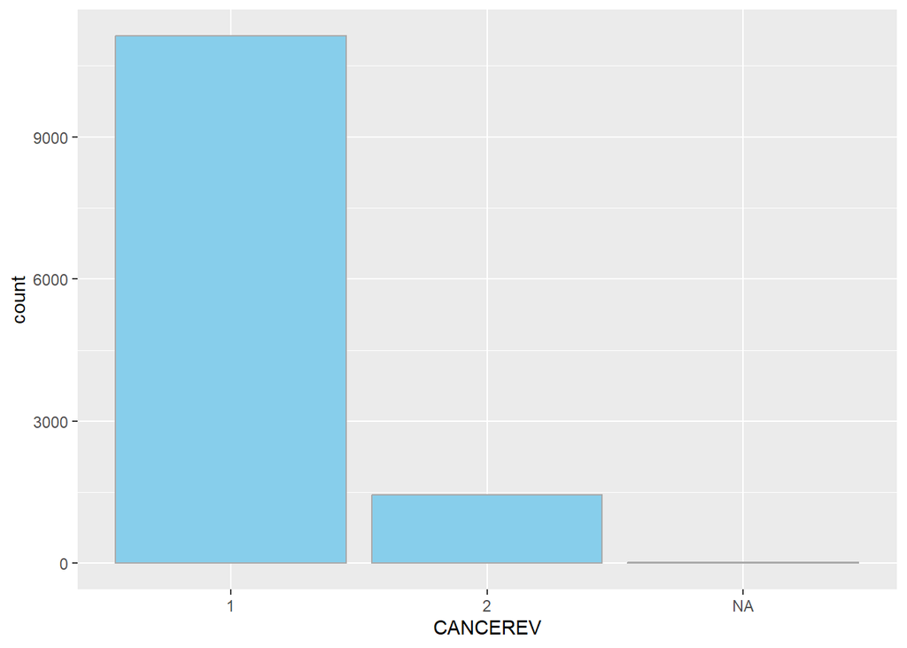

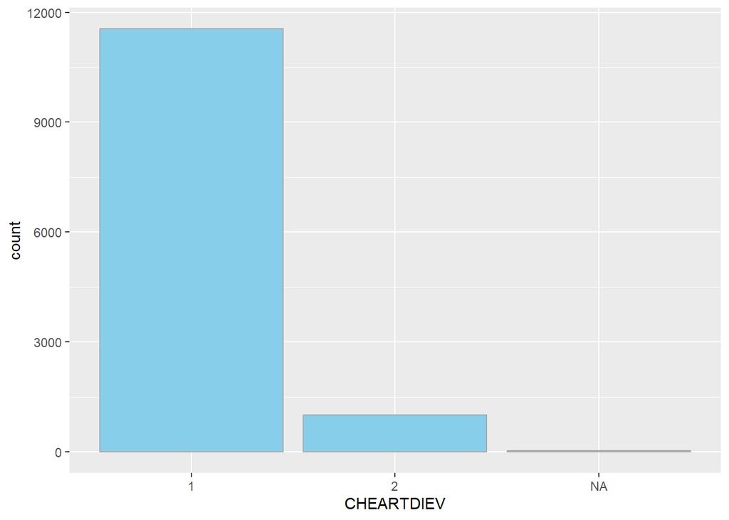

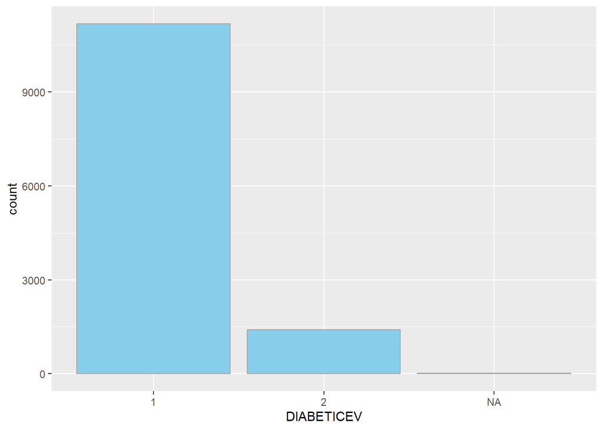

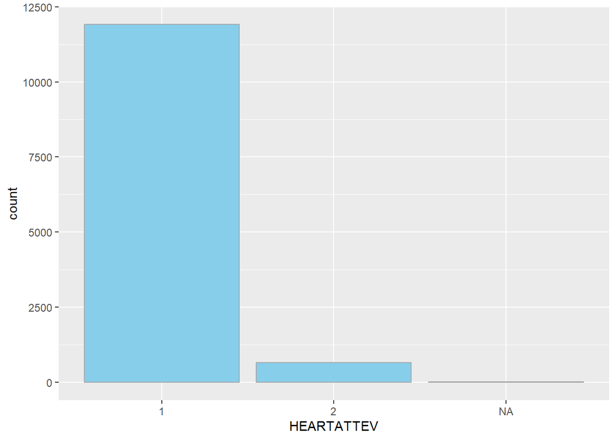

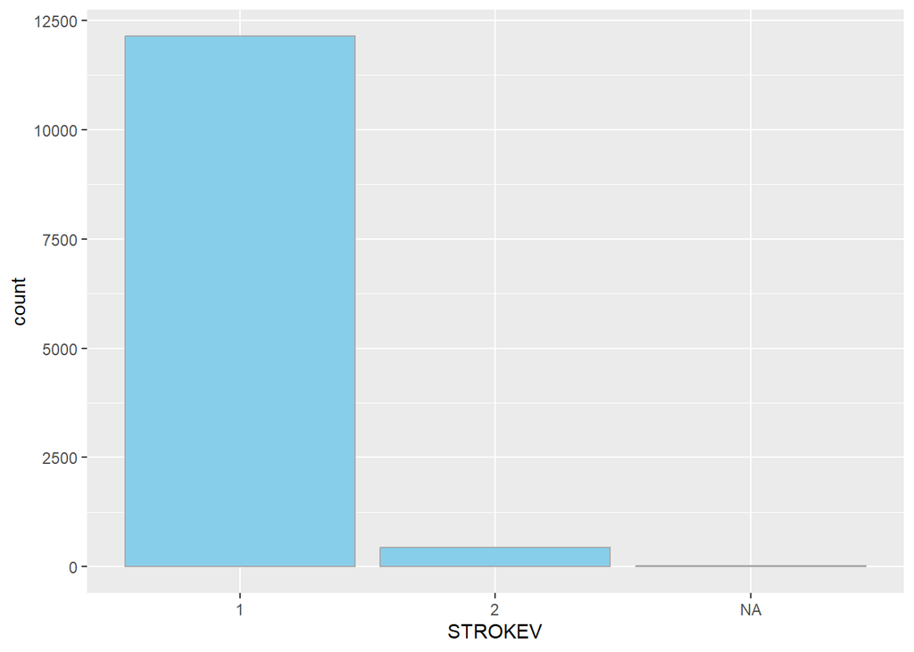

```r
for (response in responses) {
  plt <- ggplot(data=clean_ipums, mapping=aes(x=.data[[response]])) +
    geom_bar(fill="skyblue", color="darkgrey");
  print(plt);
  ggsave(paste0("output/eda/plots/", response, "_class_frequencies_bar.png"),
           plot = plt, width = 8, height = 8, dpi = "print");
}
```

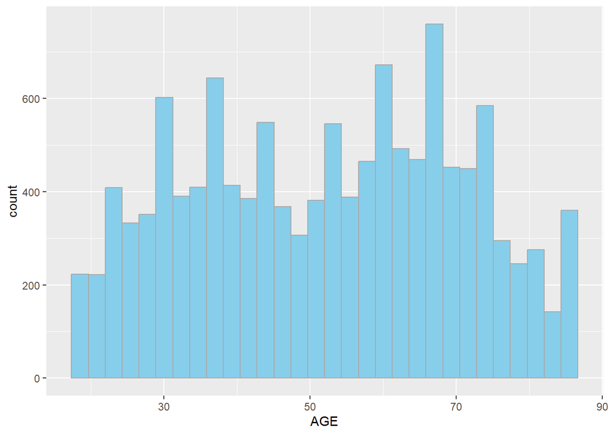

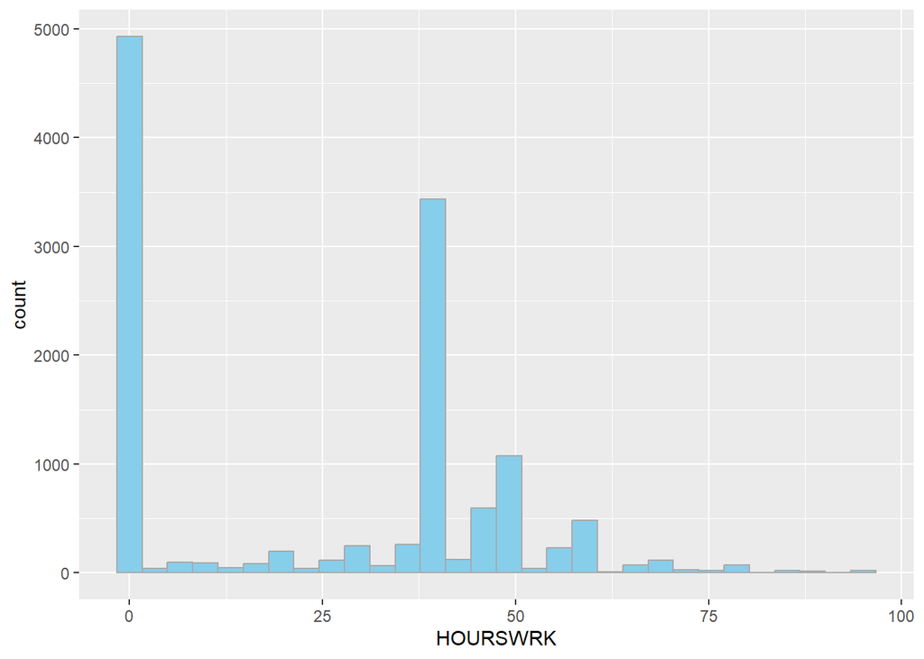

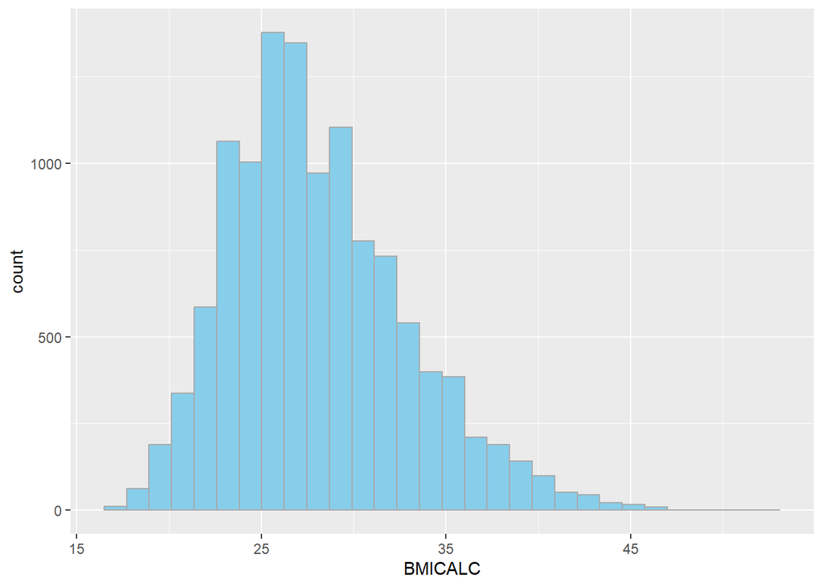

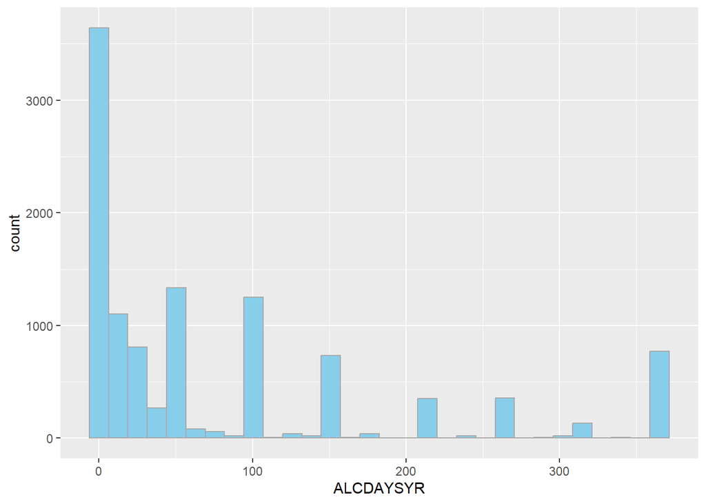

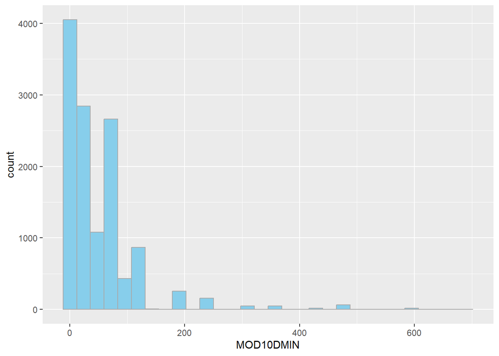

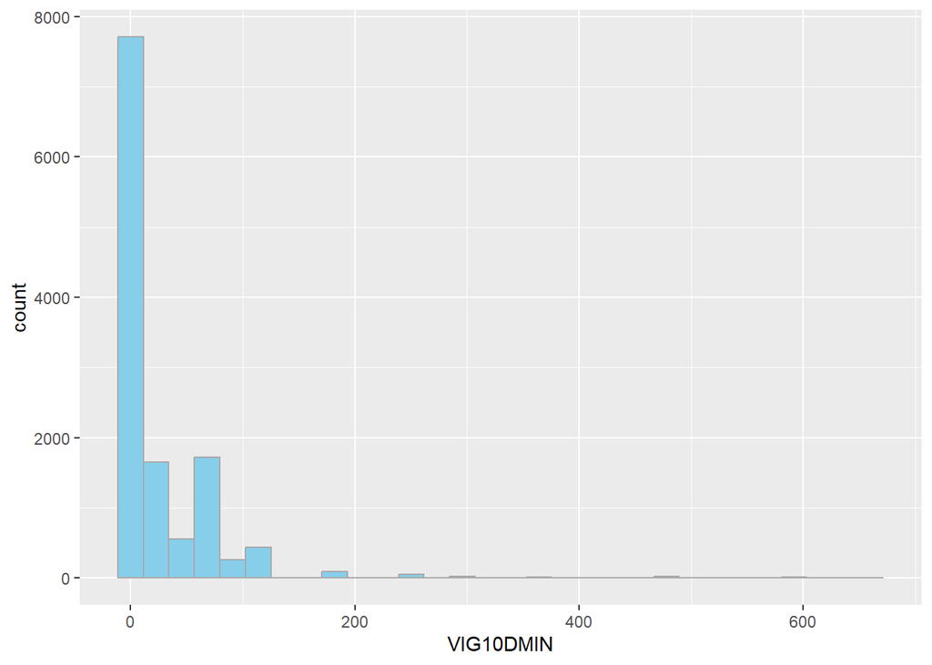

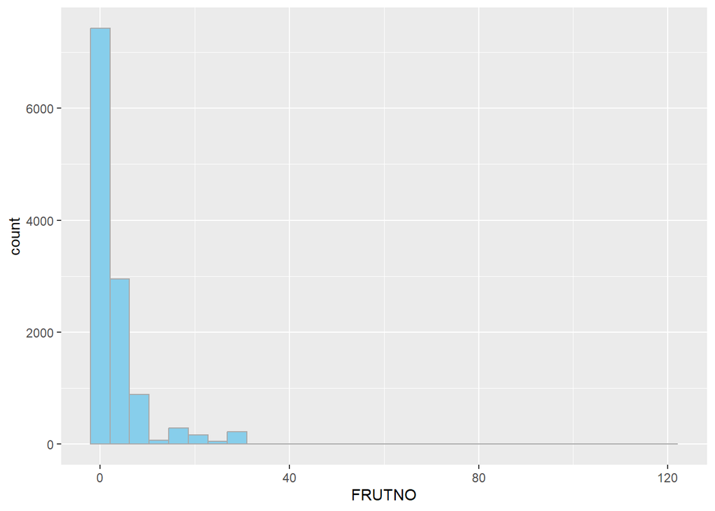

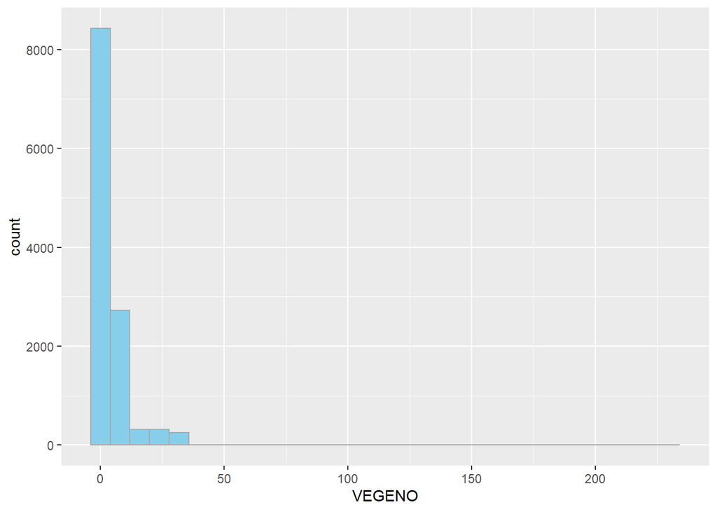

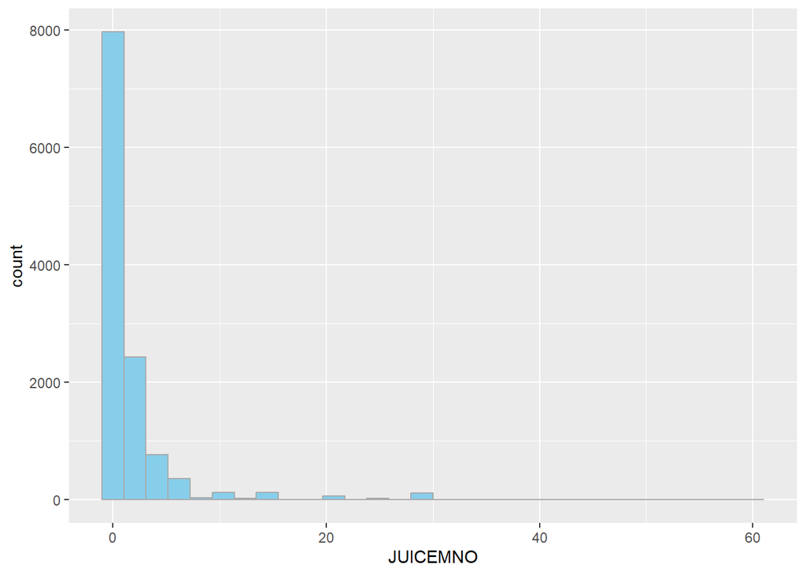

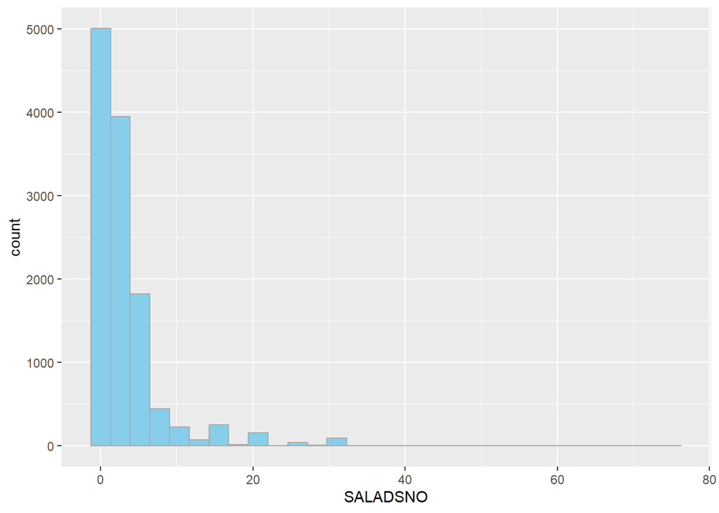

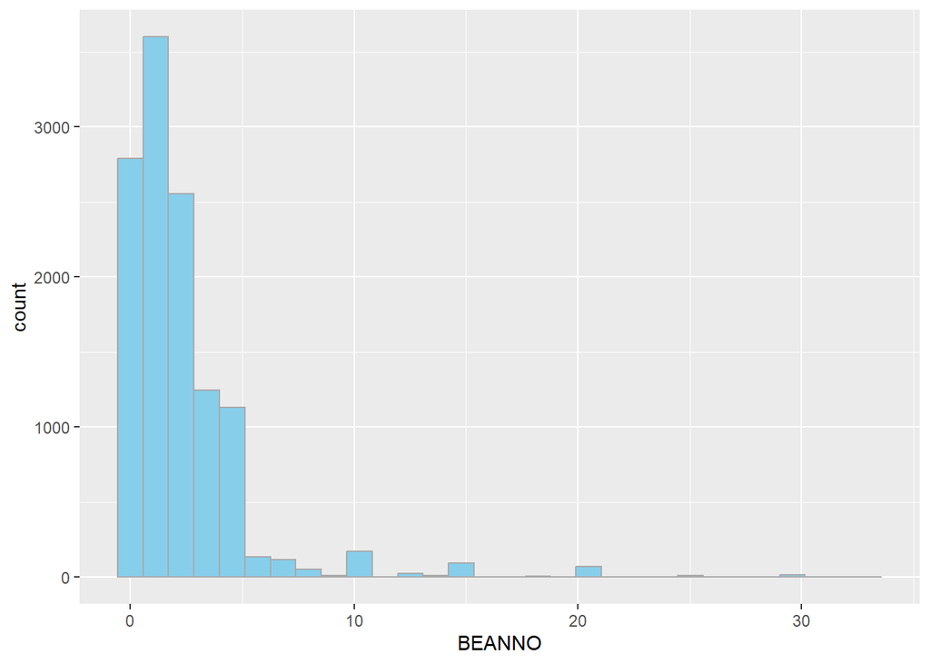

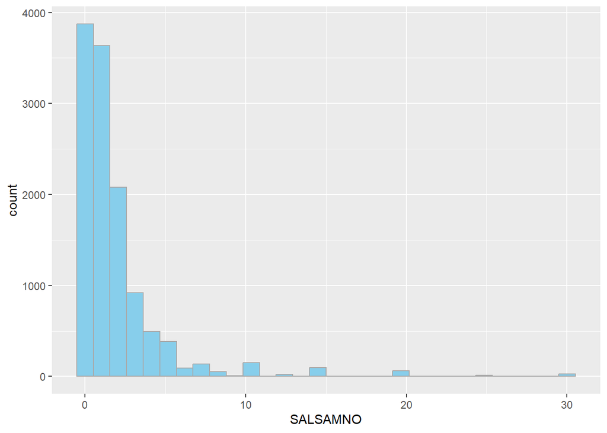

[9 more figures not shown]

```r
for (feature in features) {
  plt <- ggplot(data = clean_ipums, mapping = aes(x=.data[[feature]])) +
    geom_histogram(bins=30, fill="skyblue", color="darkgrey");
  print(plt);
  ggsave(paste0("output/eda/plots/", feature, "_histogram.png"),
           plot = plt, width = 8, height = 8, dpi = "print");
}
```

## plots of target class vs features

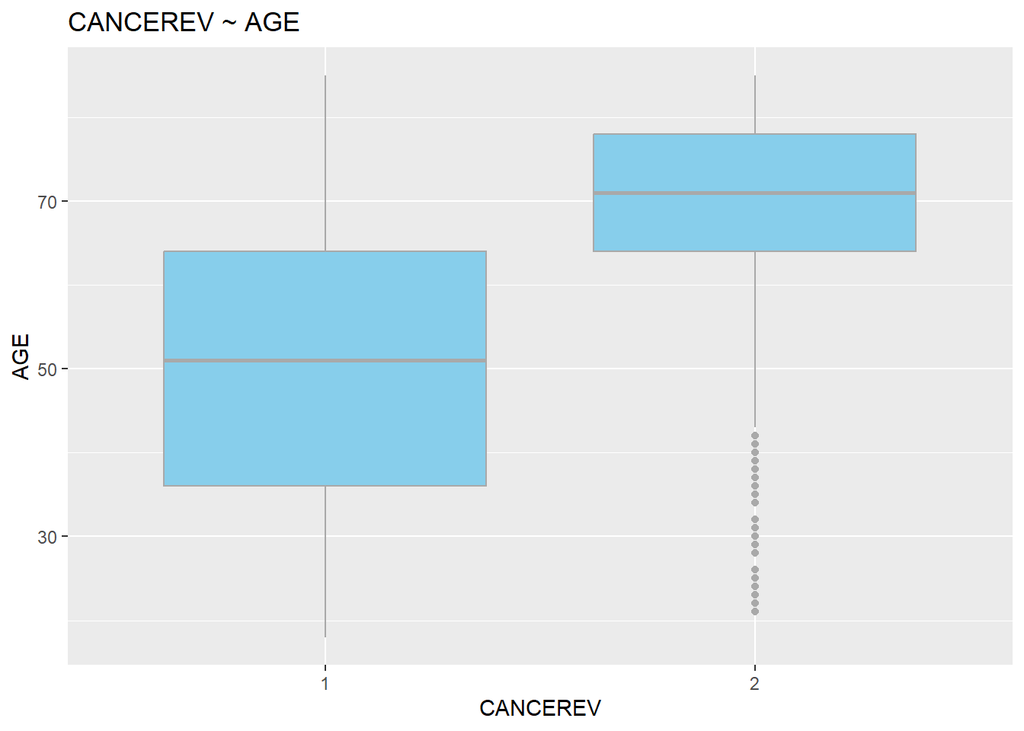

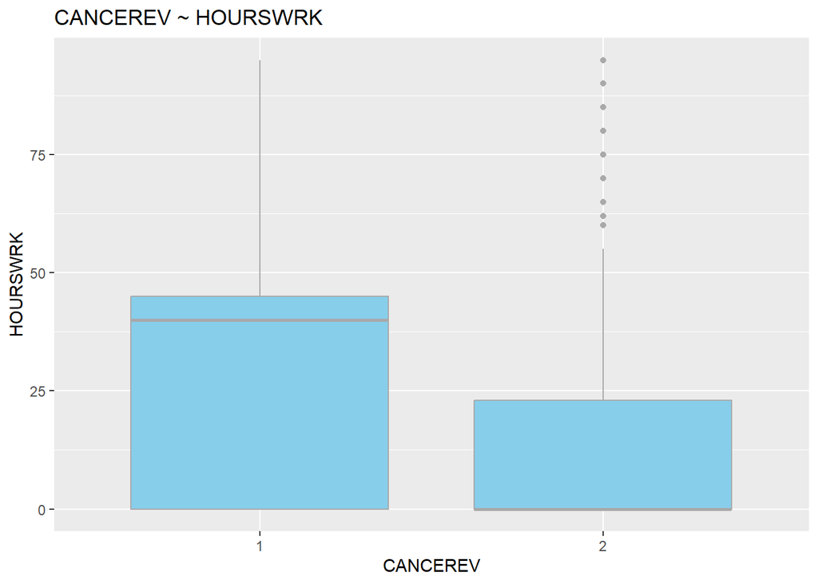

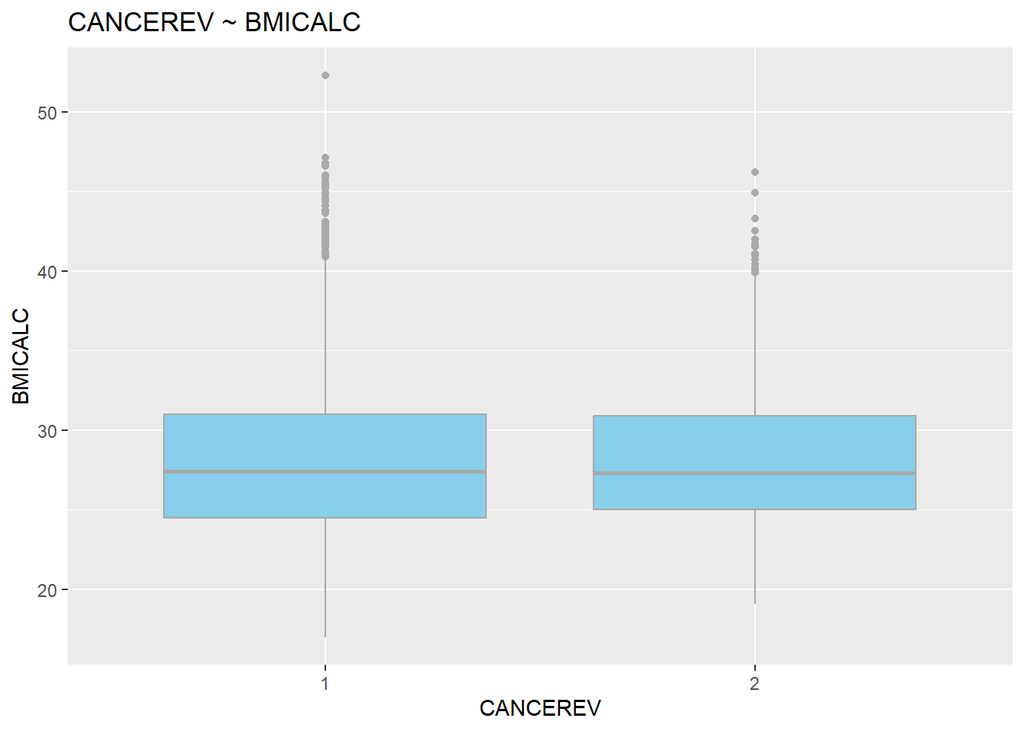

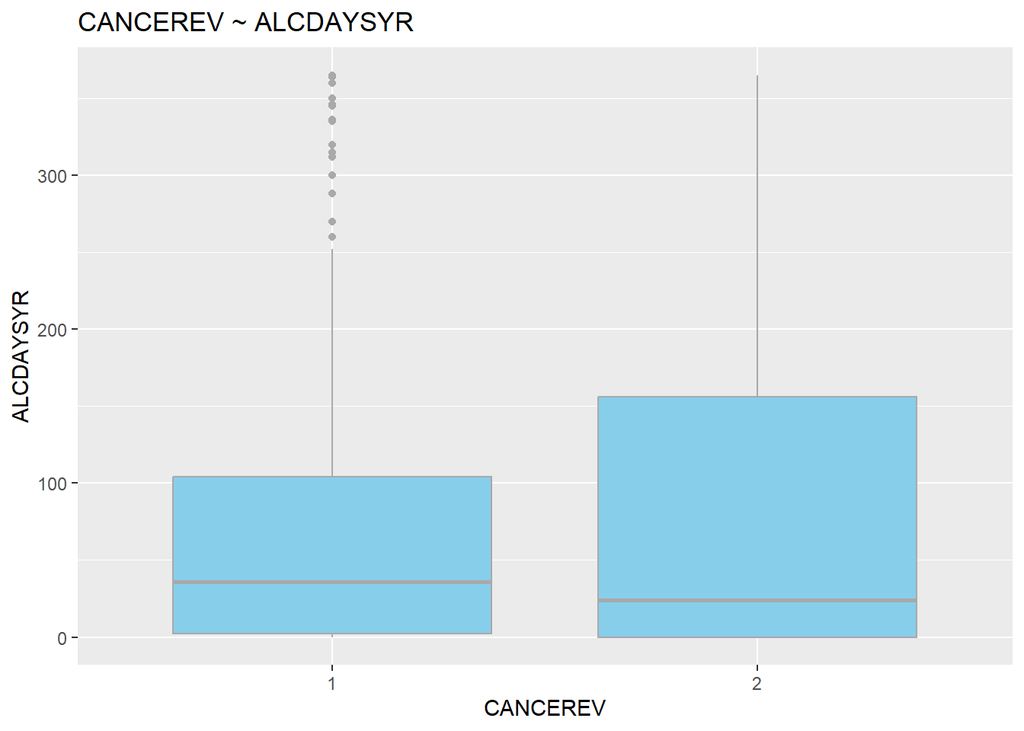

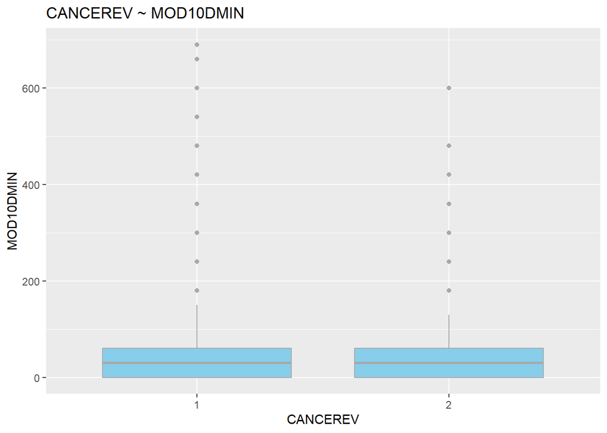

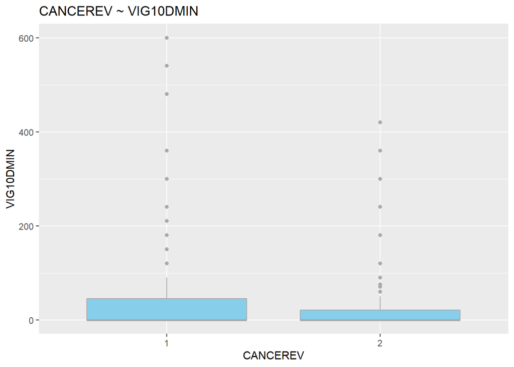

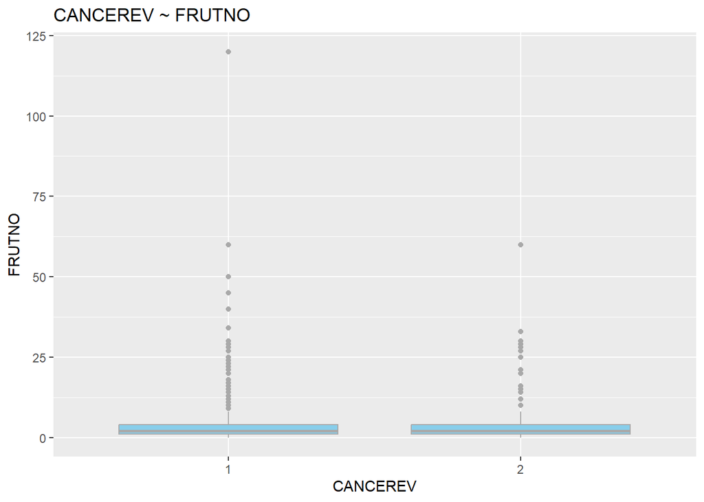

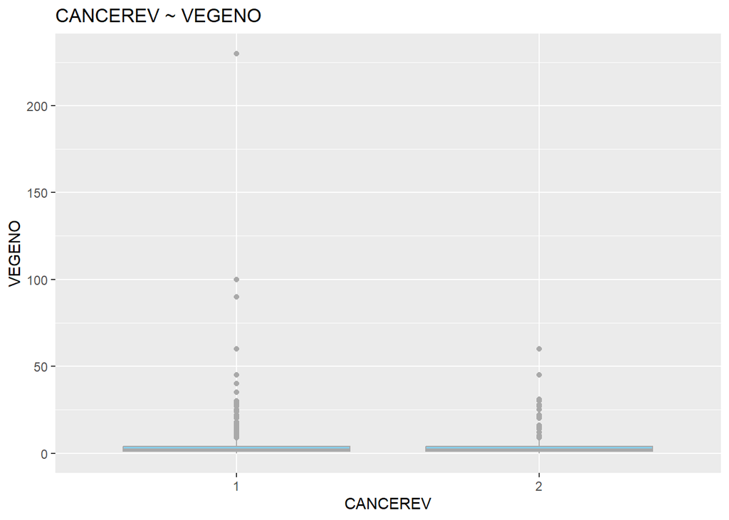

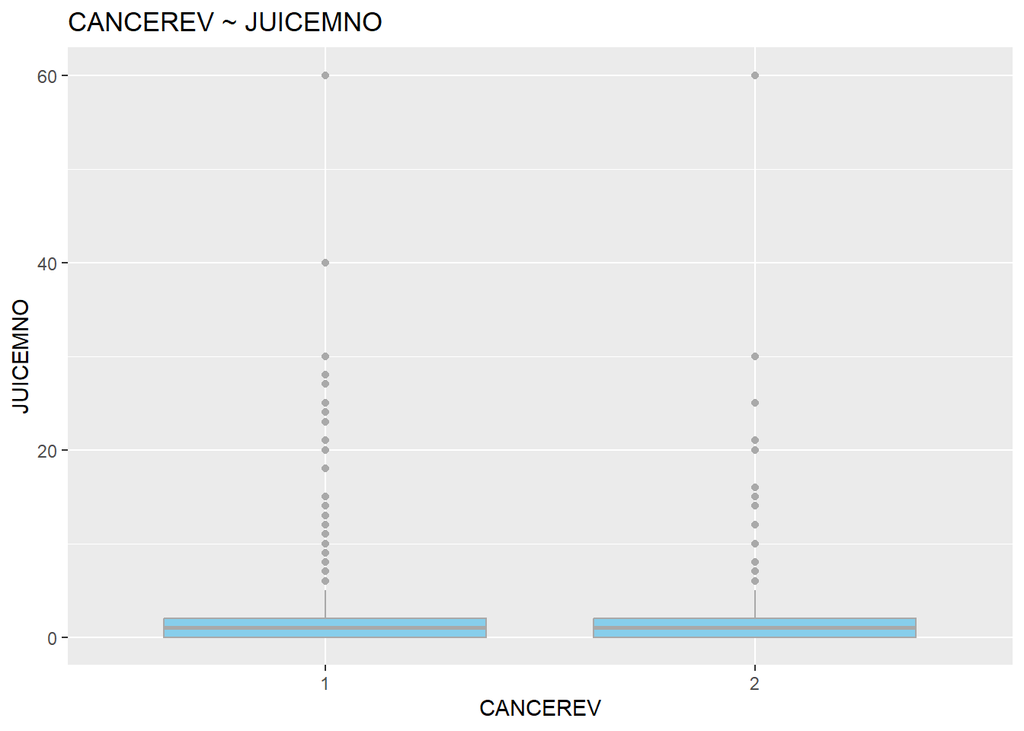

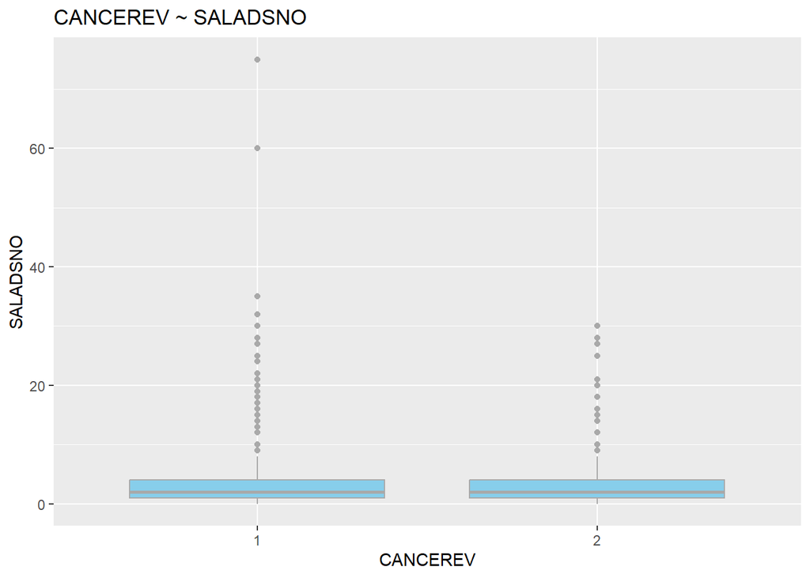

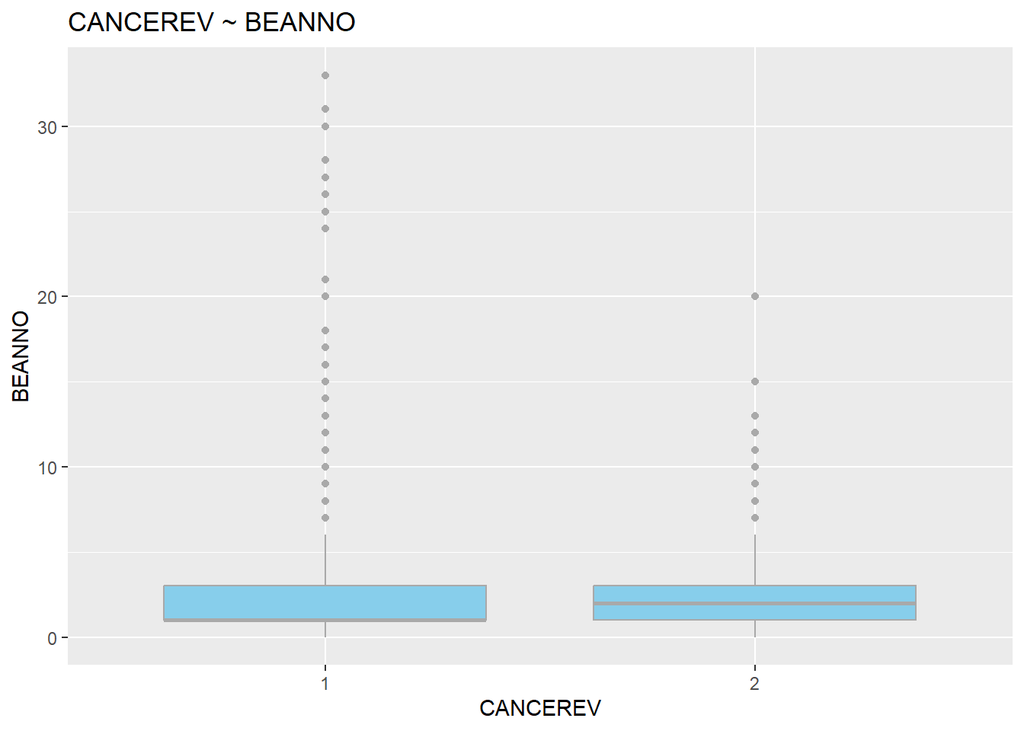

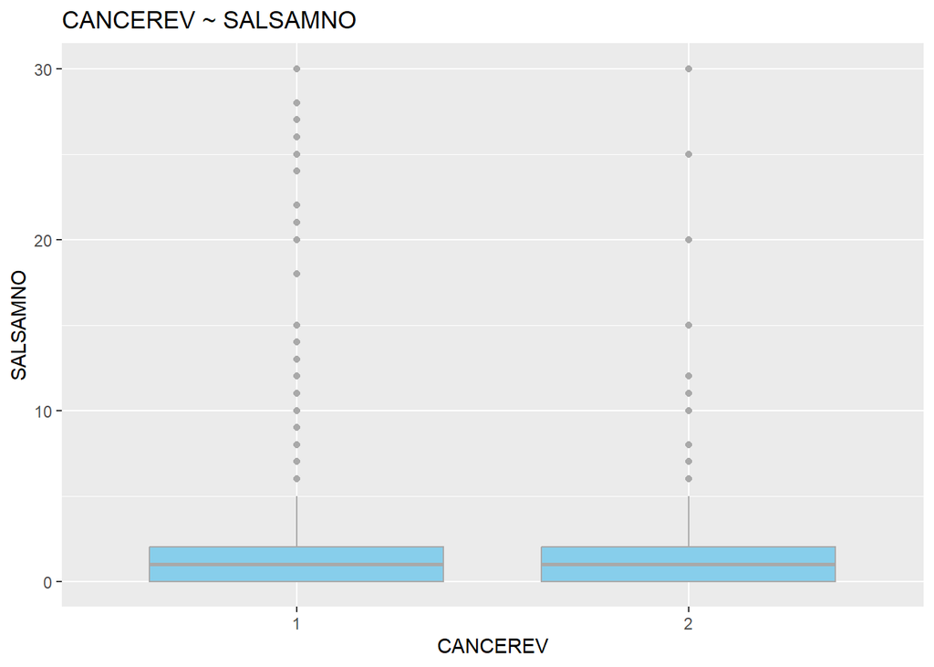

[93 more figures not shown]

```r
# to get an idea of what features and responses might be most interesting,
# lets remove na rows then plot the features vs responses
na_removed <- clean_ipums %>% na.omit();
for (response in responses) {
  for (feature in features) {
    plt <- ggplot(data = na_removed, mapping = aes(x=.data[[response]], y=.data[[feature]])) +
      geom_boxplot(position = "dodge", fill="skyblue", color="darkgrey") +
      labs(title=paste0(response, " ~ ", feature));
    print(plt);
    ggsave(paste0("output/eda/plots/", response, "_vs_", feature, "_boxplot.png"),
           plot = plt, width = 8, height = 8, dpi = "print");
  }
}
```